# Multiple forest plots

### Setting

Here is an example of a forest plot containing combined results of risk ratios and -differences for a comparison of two exposure groups from a hypothetical study. Some familiarity with the `forestploter` package is assumed. The reader might want to look at the simple forest plot before continuing.

### Data

The data contain results on number of individuals, events, along with risks for each exposure group and (displayed below) risk ratios and -differences with 95% confidence interval limits.

```r
library(forestploter)
library(grid)
library(data.table)
library(dplyr)

results <- fread("./data/RatioAndDifferenceFPdata.csv")

# empty spaces necessary for the forest function
results$blank <- "                          "
results$smallblank <- " "

# overview of selected variables
print(results[,c(1, 8:13)], digits = 5)
```

```
            level      rr  rr_lcl  rr_ucl         rd   rd_lcl   rd_ucl
           <char>   <num>   <num>   <num>      <num>    <num>    <num>
 1:       Overall 0.68126 0.63348 0.73264 -2.5491968 -3.00210 -2.09630
 2:           Sex      NA      NA      NA         NA       NA       NA
 3:        Female 0.63379 0.56410 0.71210 -2.6392561 -3.26455 -2.01396
 4:          Male 0.71725 0.65356 0.78715 -2.4467261 -3.09398 -1.79947
 5:           Age      NA      NA      NA         NA       NA       NA
 6:     <65 years 0.99311 0.70261 1.40373 -0.0049484 -0.25244  0.24254
 7:     >65 years 0.66629 0.61934 0.71680 -4.3084973 -5.03174 -3.58526
 8: Heart failure      NA      NA      NA         NA       NA       NA
 9:            No 0.64108 0.58706 0.70008 -2.3047929 -2.72852 -1.88107
10:           Yes 0.82404 0.72938 0.93100 -3.8272787 -6.15827 -1.49629
11:  Hypertension      NA      NA      NA         NA       NA       NA
12:            No 0.57571 0.48934 0.67732 -2.6357262 -3.34096 -1.93049
13:           Yes 0.71282 0.65721 0.77314 -2.5150210 -3.08566 -1.94439
```

Numbers of events, numbers at risk, and risk estimates are combined to one text variable. Text variables for risk ratios and -differences with 95% confidence intervals are also created. Some indentation is made for selected values of `level`.

```r
round1 <- function(x) trimws(format(round(x,digits = 1), nsmall = 1, scientific = FALSE))

round2 <- function(x) format(round(x,digits = 2), nsmall = 2, scientific = FALSE)

results <- results |>
  mutate(
    enr1 = case_when(
      is.na(events1) ~ "",
      .default = paste0(events1, " / ", n1, " (", round1(risk1),"%)")
    ),
    enr0 = case_when(
      is.na(events0) ~ "",
      .default = paste0(events0, " / ", n0, " (", round1(risk0),"%)")
    ),
    rr_z = case_when(
      is.na(events0) ~ "",
      .default = paste0(round2(rr), " (", round2(rr_lcl), " - ", round2(rr_ucl), ")")
    ),
    rd_z = case_when(
      is.na(events0) ~ "",
      .default = paste0(round1(rd), " (", round1(rd_lcl), " to ", round1(rd_ucl), ")")
    ),
    level = case_when(is.na(events1) | level == "Overall" ~ level, .default = paste(" ", level))
  ) |>
  select(level, enr1, enr0, starts_with(c("rr", "rd")), blank, smallblank)
```

A final touch of the data is to give the columns/variables names that will be reasonable for the forest plot

```r
colnames(results) <- c(
  "Group",
  "Events / N (risk)",
  "Events / N (risk)",
  colnames(results)[4:6], # these column names are kept as they are
  "",
  colnames(results)[8:10], # ... also these
  "",
  "",
  ""
)
```

The data are now ready for plotting.

### First draft

In order to get `forest` to make several forest plots, it is necessary to provide a list of results (point estimates and confidence interval limits). It is furthermore necessary to provide two columns where forest plots should be inserted (`ci_column` takes a vector of length 2). Note that, generally there are two specifications for parameters other than `data` in the code snippet below. The risk ratio scale has been log-transformed while the risk difference scale is kept linear - mostly just show it is possible. Note that column 13 (the small blank) is included several times for padding, this might not be strictly necessary.

```r
p <- forest(
  data = results[,c(1,13,2,13,3,13,7,12,13,11,12)],
  est = list(results$rr, results$rd),
  lower = list(results$rr_lcl, results$rd_lcl),
  upper = list(results$rr_ucl, results$rd_ucl),
  ci_column = c(8, 11),
  vert_line = list(1, 0),
  x_trans = c("log", "none"),
  xlim = list(c(.5, 1.5), c(-6.5, 2.5)),
  ticks_at = list(c(.5, .75, 1, 1.5), c(-5, -2.5, 0, 2.5))
)
```

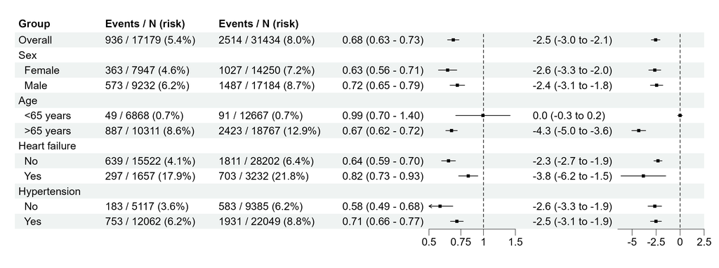

Figure 1: Forest plot with risk ratios and -differences

### Prettification … well aesthetics are subjective anyway

```r
# theme specification
tm <- forest_theme(
  base_size = 15,
  ci_pch = 19,
  ci_lwd = 3,
  ci_col = "#6a4a4a",
  refline_gp = gpar(col = "grey"),
  core = list(
    bg_params = list(fill = c("#ffe2e3", "white")),
    padding = unit(unit(c(5,5), "mm")) # universal padding around cells in x and y direction
  ),
  colhead = list(padding = unit(c(5,7), "mm")) # padding in headers
)

p <- forest(
  data = results[,c(1,13,2,13,3,13,7,12,13,11,12)],
  est = list(results$rr, results$rd),
  lower = list(results$rr_lcl, results$rd_lcl),
  upper = list(results$rr_ucl, results$rd_ucl),
  ci_column = c(8, 11),
  vert_line = list(1, 0),
  x_trans = c("log", "none"),
  xlim = list(c(.5, 1.5), c(-6.5, 2.5)),
  ticks_at = list(c(.5, .75, 1, 1.5), c(-5, -2.5, 0, 2.5)),
  theme = tm
)

# add headers
p <- add_text(
  p,
  text = "Intervention group",
  col = 3,
  row = 0,
  part = "header",
  gp = gpar(fontface = "bold", fontsize = 15)
)

p <- add_text(
  p,
  text = "Control group",
  col = 5,
  row = 0,
  part = "header",
  gp = gpar(fontface = "bold", fontsize = 15)
)

p <- add_text(
  p,
  text = "Risk ratio (95% CI)",
  col = 7:8,
  row = 1,
  part = "header",
  gp = gpar(fontface = "bold", fontsize = 15)
)

p <- add_text(
  p,
  text = "Risk difference (95% CI)",
  col = 10:11,
  row = 1,
  part = "header",
  gp = gpar(fontface = "bold", fontsize = 15)
)

# center algning relevant columns
p <- edit_plot(
  p,
  col = 3:7,
  part = "body",
  which = "text",
  hjust = unit(.5, "npc"),
  x = unit(.5, "npc")
)

# center aligning the headers in the plot
p <- edit_plot(
  p,
  col = 3:7,
  part = "header",
  which = "text",
  hjust = unit(.5, "npc"),
  x = unit(.5, "npc")
)

# bold facing selected labels
p <- edit_plot(
  p,
  col = 1,
  row = c(1, 2, 5, 8, 11),
  part = "body",
  which = "text",
  gp = gpar(fontface = "bold")
)
```

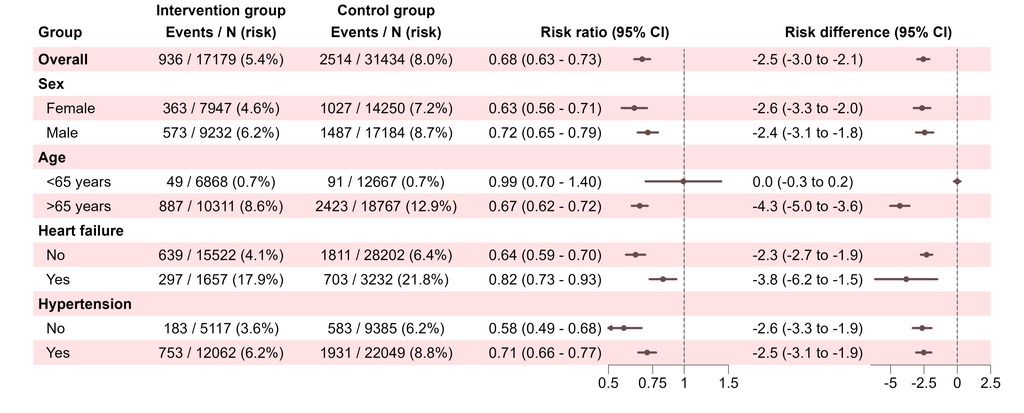

Figure 2: Custom themed forest plot with risk ratios and -differences